# The MovieLens Dataset

Nicola Gennaro

September 2018

## The MovieLens Dataset

**MovieLens** is a web-based recommender system and virtual community that recommends movies for its users to watch, based on their film preferences using collaborative filtering of members’ movie ratings and movie reviews.

The dataset contains:

- over 1.000.000 ratings
- from more than 6.000 users
- about 4.000 movies

The dataset is divided in three tables: Users, Movies and Ratings. It contains informations both about the users, like age, sex and occupation, and also about the movies, like genre and year of release. The rating system is based on the five stars classification, like many other datasets of this kind.

In the first part of this report we’re going to explore and analyze the kind of data we are dealing with, while in the second part the attention will be focused on finding relationships between the users’ main features and their movies tastes. Let’s start with the Users table.

## The Users Dataset

As already mentioned in this table we can find information like users’ sex, age, occupation but also their zipcode, that will allow us to track their geographical position. Here we can see the first rows of this table:

| userID | gender | age | occupation | zipCode |
| --- | --- | --- | --- | --- |
| 1 | F | <18 | K-12 student | 48067 |
| 2 | M | 56+ | self-employed | 70072 |
| 3 | M | 25-34 | scientist | 55117 |
| 4 | M | 45-49 | executive/managerial | 2460 |
| 5 | M | 25-34 | writer | 55455 |

Let’s now explore a little bit these features starting with the gender:

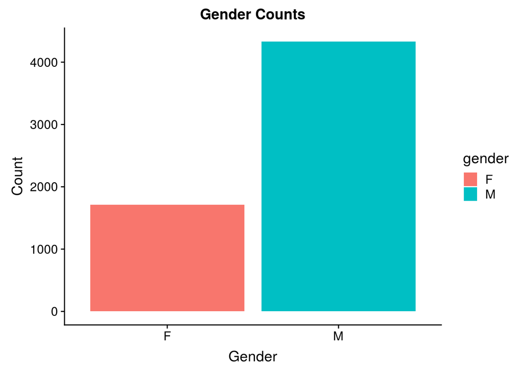

As clarified by this histogram there is a strong disproportion in the genders, more of 70% of users is a male, while one would expect them to be near 50%. Even if we can legitimately assume that males are simply more numerous because they are more likely to use this kind of service, we have to remember that in the case of a family generally is the man who gives the name for the account, while, after that, the whole family can use it. If this is the case, the data related to users, like age and occupation may be wrong or at least not completely correct. This is a problem we cannot solve, and unfortunately our entire analysis will be based on this data.

Another main feature of users in this database is age:

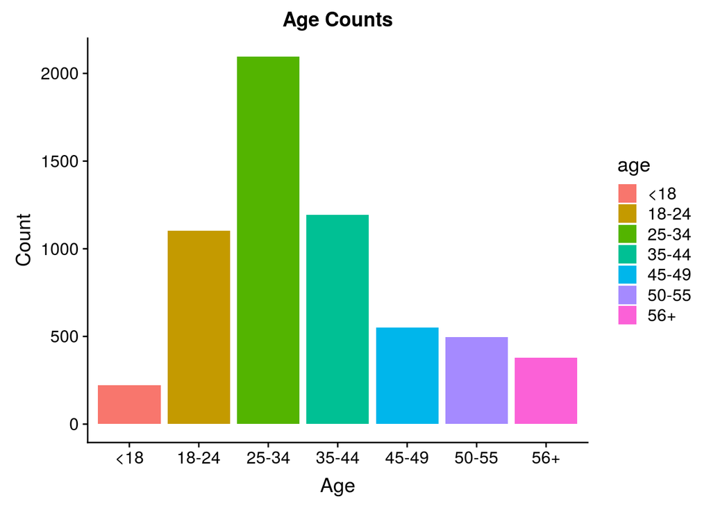

As we can see ages are divided in 7 categories, ranging between under 18 and over 56. The histogram above shows that the majority of users are young adults, expecially in the 25-34 range.

To each user is associated one of 20 possible occupations, with also the possibility of the “other” category, that seems to be one of the most numerous.

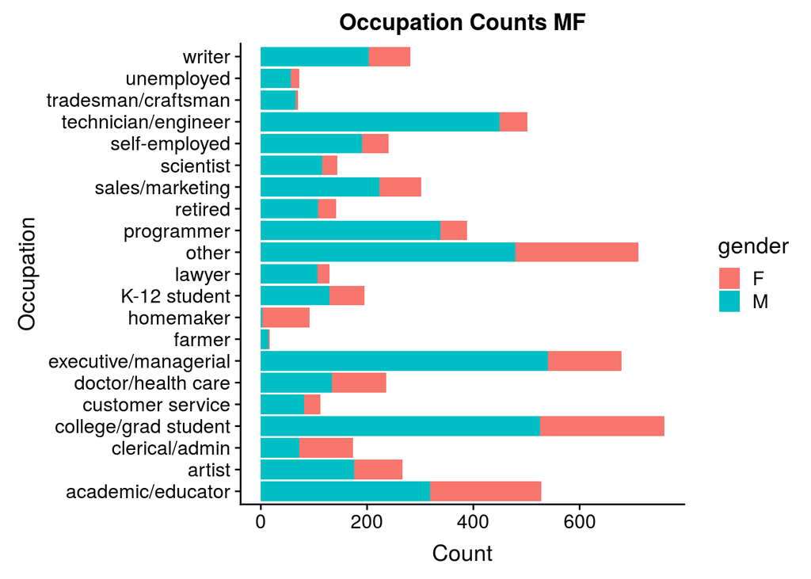

In the histogram the colors denote the gender of the user, but this is not very informative, since the proportion of males and females is not equal. To better understand how the gender is associated to a specific occupation, a plot like the following one is better. Here the width of the bar represent the proportion of a gender for each occupation, while the vertical line correspond to the overall proportion of male users.

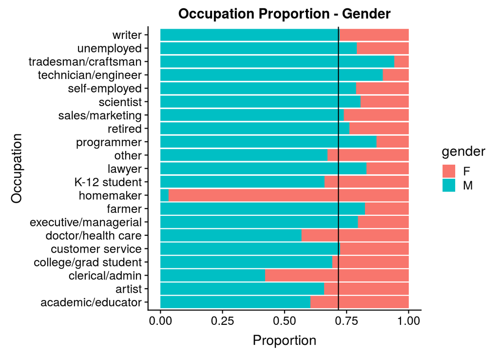

The most unbalanced profession is the homemaker, as was to be expected, but also in the clearical/admin and in the medical field there is a notable disproportion in favour of women. Craftsman, technician, programmer and lawyer are instead more “male” jobs (according to these data).

The following diagram, represent again the occupation proportion of the users, but this time the colors correspond to their ages.

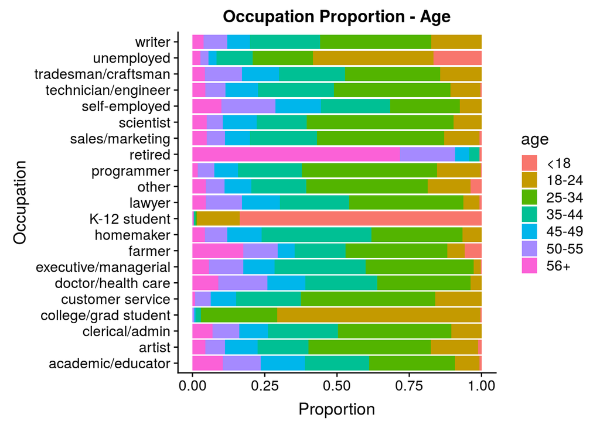

The most notable disproportions are in the students classes, both “college/grad” and “K-12”, and in the “retired” one, that of course are strongly related to age. Also being an unemployed seems to be related to age, young people, expecially those in the 18-24 category dominates this class.

## Using ZipCode to track users’ position

Since MovieLens provides only the Zipcode of the users, I joined this dataset with one made available from the post service, in order to have all the other informations that can be deduced from the postal address. In particular we have at our disposal the city, state and geographical coordinates of our users. It comes out that, with the exception of five users, all of them live in USA, and in particular from the continent, as we can see from the plot below, obtained with longitude and latitude of the accounts.

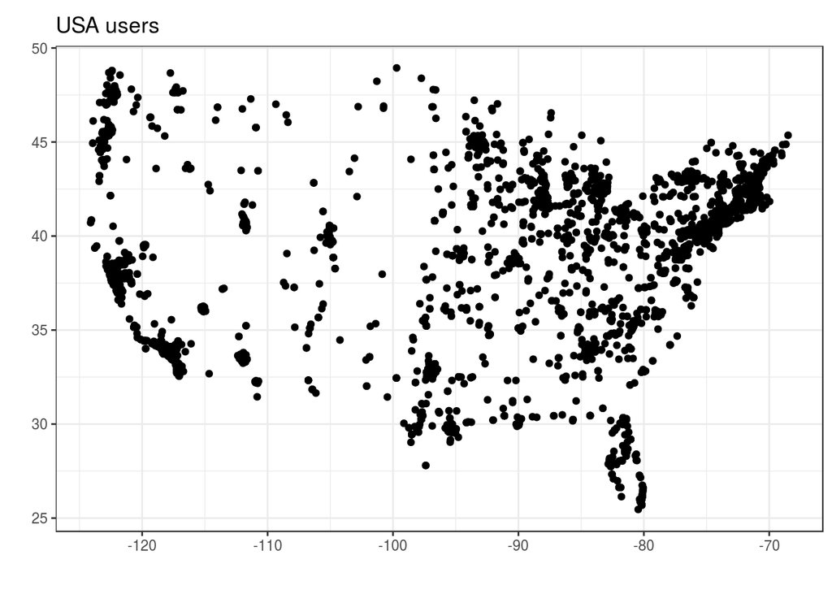

## The Movies Dataset

This second table contains informations like title, year and genres for each movie in the dataset. In particular since one movie can goes under more that one genre, these are one-hot encoded with zeros and ones. In the following we’re briefly going to analyze this table and its content.

| movieID | title | year | Action | Adventure | Animation |
| --- | --- | --- | --- | --- | --- |
| 1 | Toy Story | 1995 | 0 | 0 | 1 |
| 2 | Jumanji | 1995 | 0 | 1 | 0 |
| 3 | Grumpier Old Men | 1995 | 0 | 0 | 0 |
| 4 | Waiting to Exhale | 1995 | 0 | 0 | 0 |
| 5 | Father of the Bride Part II | 1995 | 0 | 0 | 0 |

For example the histogram below show that, as expected, the majority of movies present in this dataset were produced in the last years, but also old movies are present.

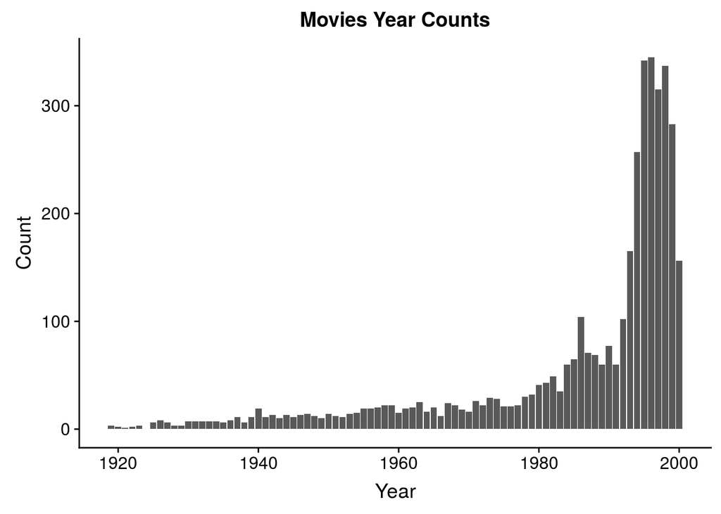

In the diagram below, instead, there are the number of genres appearing in the whole dataset. As mentioned before one movie can have more than one genre, so the sum of them all is higher than the number of movies in the dataset. Having more than one genre can be confusing for our purpouse of analysis, but the truth is that the majority of movies has just one or two of them, so it’s not such a big deal. Drama and Comedy are by far the most numerous genres followed by Action, Thriller and Romance. In the final analysis about the relationship between users’ features and movies tastes, I’m going to consider only a few of them, in particular I chose those that, according to me, seemed to be the most likely to be associated to a particular users’ class.

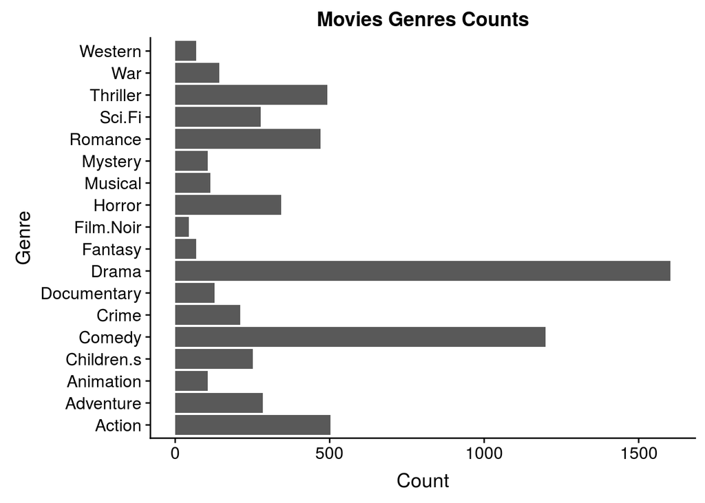

## The ratings dataset

The last part of the dataset regards the ratings given by the users. There are more than 1 million of them and the creators ensures that each users rated at least 20 items. This table contains only the ratings, in the five stars systems, and the timestamps of the rating. As done before, we’re going to spend a few words also on this one.

| userID | movieID | rating | time |
| --- | --- | --- | --- |
| 1 | 1193 | 5 | 2000-12-31 |
| 1 | 661 | 3 | 2000-12-31 |
| 1 | 914 | 3 | 2000-12-31 |
| 1 | 3408 | 4 | 2000-12-31 |
| 1 | 2355 | 5 | 2001-01-07 |

The leftmost of these two plot shows the count for each of the five starts. The majority of the ratings correspond to three and four stars, and suggest that, as one can imagine, people tend to see, and thus rate, movies they know they will probably like. This is confirmed by the plot on the right, that simply shows the mean and the standard deviation of the ratings. The mean is higher than 3, that would have been the mean value in the case of a uniform distribution over the five stars, thus confirming the previous hypothesis.

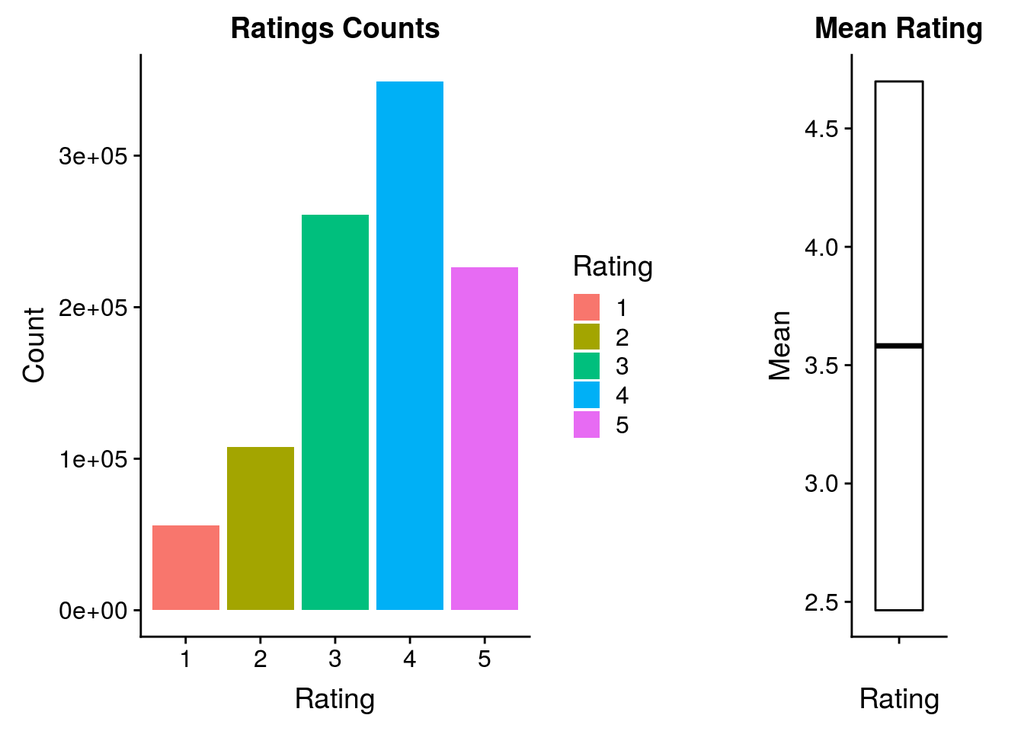

The following histogram shows the proportion of male and female ratings (and not the proportion of male-female users discussed before). The dashed line represent the overall proportion of males in the ratings, while the solid one is instead the proportion of males between the users. The fact that the male proportion for the ratings is higher than the proportion for the users suggest, as pointed before, that male users tend to be more active users than female.

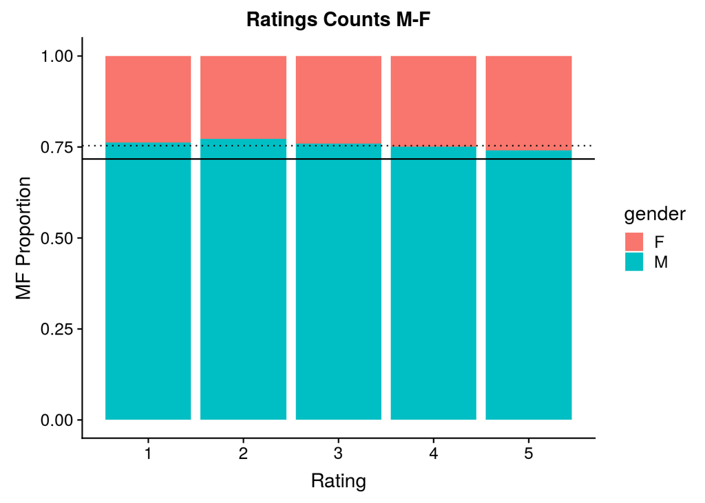

It’s also interesting what happens if we plot the five ratings against the proportion for each age class. The pattern shows that older users tend to give slightly higher votes than younger ones. One possible explaination is that they probably know better what they like, but we’re going to tell something about this fact in the next chapter, when we’re going to talk about the relationship between the year of a movie and the age of a user.

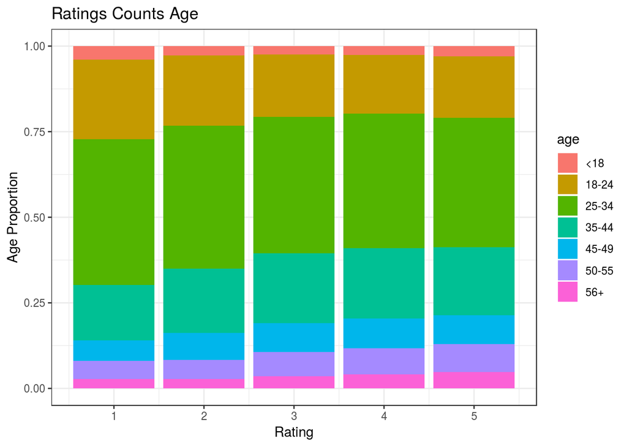

## Final Analysis

Now we’re going to analize the possible relationship between the features of movies and those of users, to see if it is possible to predict a user’s taste only by using his personal data. Just a few lines above we talked about the fact that older users tend to give higher votes, and we assumed that this is because they know their tastes. The following plot will tell us more about this. The next figure shows the mean year of movies rated by a particular age category, and it is pretty clear that the older the users are, the older are also the movies they have rated. So we can imagine that older users have rated movies they have already seen, or at least movies that belongs to the period of they youth, and probably this is the reason why their mean vote is higher than that of younger ones. They simply tend to rate movies they have already seen and that they liked.

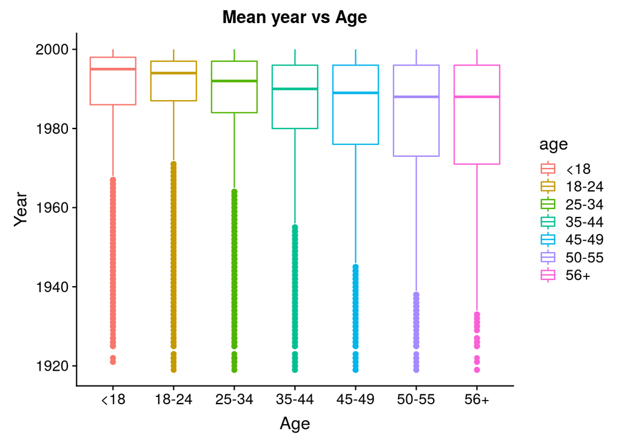

To simplify the following analysis, we’re going to divide the movies in decades instead of considering the single years. Following the above reasoning we can expect that the mean rate for older movies should be higher for the older class of people. But the following plot, that for each decade shows the mean rating for each age category together with its standard deviation, shows that this is only partially true.

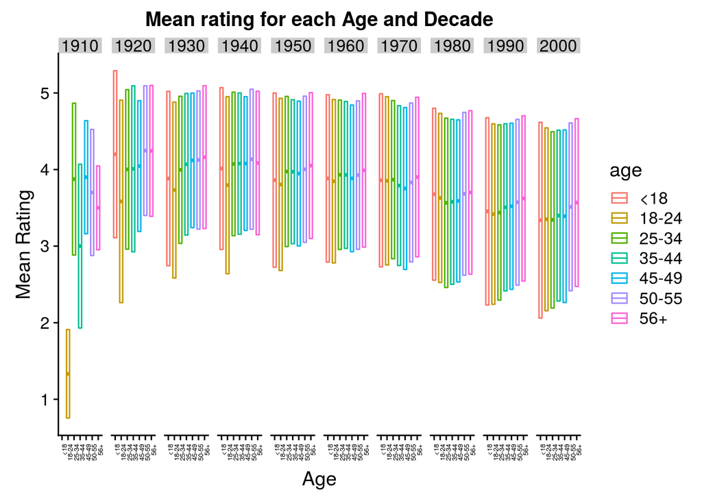

As one can see the mean vote tend to be higher for older users, but this is true for each decade, and this is more evident especially in the last two decades, i.e. for the most recent movies. So the higher mean rating of older users is not due to the fact that they see old movies, but is a fact that extends to all kind of movies. The previous hypothesis that explain the higher ratings with already seen movies is to be discarded. We can simply assume that older people tend to give better votes, but probably the fact that they know their tastes, and know in advance what movie they will like, is a better explaination. In the 20’ categories, but particularly in the 10’, the pattern is totally random, but this is due to the small number of movies in these classes. This plot shows also another pattern that is worthy to be analized, the overall mean rating tend to decrease with the decade of the movies. We can now plot the same features but in a different perspective: in this plot the mean ratings are grouped by age instead of decade.

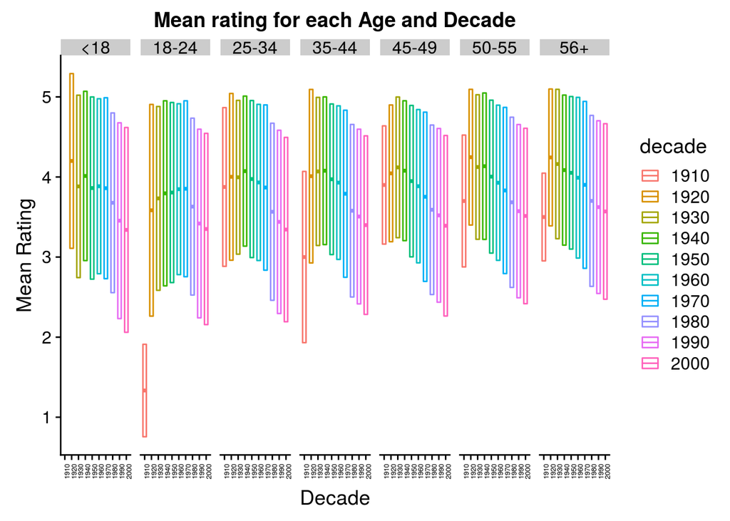

So it seems that older movies are more appreciated by all kind of users, regardless of age. Maybe this last reasoning needs a little bit of recap: what the data are telling us is that older movies, in general, are more appreciated by people, because on the average they have the higher vote. But, when one looks at the mean for each single age class, it is clear that older users give higher votes, indipendent of the movie year or decade.

Now we’re going to analize in deatail the relationship between the users features and movies genres, that is for sure a more important feature for a movie than the year of production. Since there are a lot of genres, I decided to focus the attention only on a few of them, in particular those that to me seems to be more peculiar, and, in my opinion, more likely to be associated to one of the classes in which users are divided. These genres are: Drama, Comedy, Action, Horror, Western, Romance, Childrens’, Musical and War. First we’re going to analize the relationship between genre and sex:

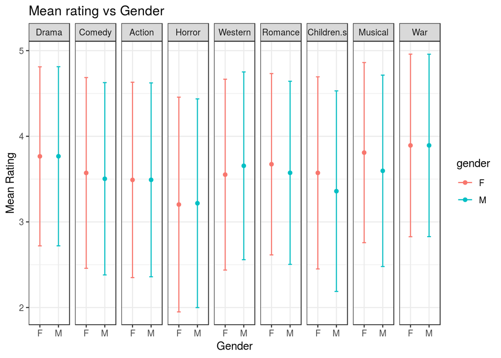

As we can see, ever if there are some differences, these are not so significant. But for example Western movies are preferred by male users, while Musical, Romance and Childrens’ movies are preferred by women. All the most common genres like Drama and Comedy instead doesn’t show a particular preference by one of the two genders. Surprisingly even genres like Action and War shows no difference, in fact the two mean ratings are the same.

Again we can analize if there are some diffences between ages in their relationship with the movies’ genres but the plot below displays the same pattern we have encountered above, showing that in general the mean rating increase with age, indipendently of the genre. Only for Horror movies the mean rating is stable within the ages groups and this is also lower than the other genres. So, in general, people do not like horrors.

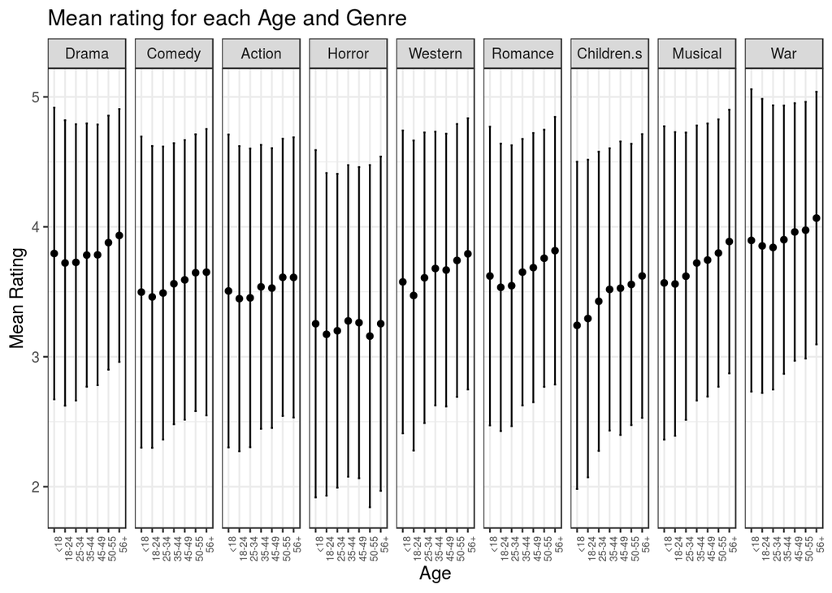

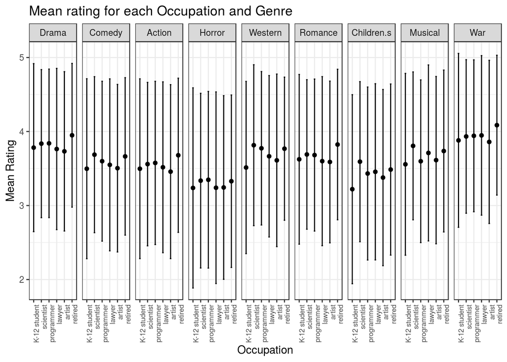

## Conclusions

In this report we have analyzed the MovieLens dataset and the kind of informations it can provide, and then we tried to use these informations to analyze the users’ tastes and their movies preferences, but, in the end, little can be said about them. Let’s resume our results:

- Age is slightly related to the year of rated movies and older users tend to rate older movies.
- In general older movies received higher votes, while older people give higher votes.
- Gender is slightly related to the movies’ genre but only for some of them (especially Musicals and Childrens’ movies)
- The occupation of a user contain no information about his/her tastes.

So, at the end, it seems that general informations about the users, like sex, gender and profession, are only slightly related to movies’ preferences. We mentioned the fact that the data may be fuzzy, because the accounts can be used by more than one person at the time, and maybe this is one of the reasons why our analysis seems to yield so negative results. But after having said that, we have to remember that services like MovieLens or Netflix use some much more sophisticate approaches for their reccomendations, like Collaborative Filtering (suggesting items consumed by users that are “similar” to the one in consideration) or Content-Based Filtering (suggesting items similar to those already consumed by a user). Probably this is because they already know that nothing useful can be extracted by general informations about users.